# Aggregate Forecasts or Aggregate Data

Bahman Rostami-Tabar and Dejan Mircetic April 20, 2020

(\alpha) - version

#Adding the accuracy function

#Forecasting h-steps ahed

Loading of forecasts depending the h-steps ahead

(Dodati sad ovdje finalne slike tacnosti za svaki pristup iz foresee fajla)

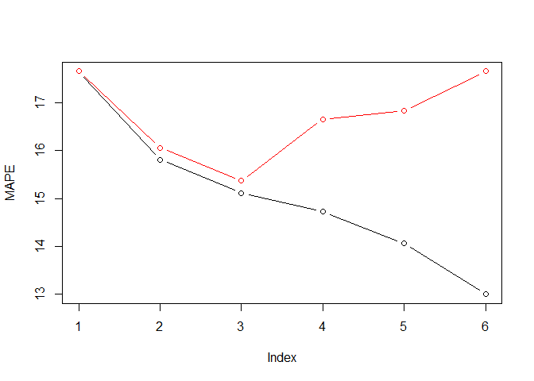

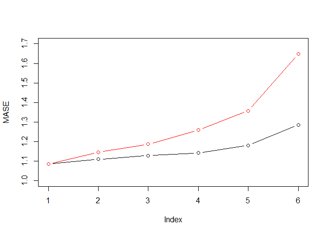

#Comparison

#Add characteristics

#Features extended

#Making classification data base Obrati paznju uvedi kriterijum za neke metrike treba da ide suprotan znak PROVJERITI DA LI JE MARKS FAKTORI I KAKO IYGLEDA CLASS TABLE

#Logistic regression

```
##
## Call:
## glm(formula = marks ~ . - x_acf10 - x_acf1 - seas_acf1 - e_acf1 -
##     e_acf10 - diff1_acf1 - diff1_acf10 - diff2_acf1 - diff2_acf10,
##     family = binomial, data = train.data[, -1])
##
## Deviance Residuals:
##     Min       1Q   Median       3Q      Max
## -1.5923  -1.4017   0.9045   0.9457   1.2628
##
## Coefficients:
##                    Estimate Std. Error z value Pr(>|z|)
## (Intercept)        0.549053   0.011379  48.252  < 2e-16 ***
## trend              0.159902   0.024997   6.397 1.59e-10 ***
## spike              0.012788   0.012833   0.996 0.319026
## linearity         -0.064237   0.013234  -4.854 1.21e-06 ***
## curvature         -0.028282   0.011594  -2.439 0.014717 *
## entropy           -0.047139   0.025183  -1.872 0.061229 .
## seasonal_strength -0.041235   0.012350  -3.339 0.000841 ***
## peak               0.011640   0.011915   0.977 0.328627
## trough             0.006387   0.012104   0.528 0.597757
## ---
## Signif. codes:  0 '***' 0.001 '**' 0.01 '*' 0.05 '.' 0.1 ' ' 1
##
## (Dispersion parameter for binomial family taken to be 1)
##
##     Null deviance: 44180  on 33599  degrees of freedom
## Residual deviance: 43886  on 33591  degrees of freedom
## AIC: 43904
##
## Number of Fisher Scoring iterations: 4

##             trend             spike         linearity         curvature
##          5.147560          1.340083          1.329304          1.025493
##           entropy seasonal_strength              peak            trough
##          5.084984          1.177922          1.097912          1.134143
```

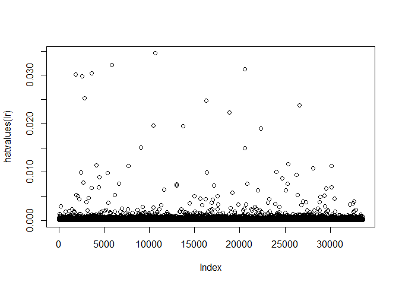

```
##
## Call:
## glm(formula = marks ~ . - peak - trough - spike - x_acf10 - x_acf1 -
##     seas_acf1 - e_acf1 - e_acf10 - diff1_acf1 - diff1_acf10 -
##     diff2_acf1 - diff2_acf10, family = binomial, data = train.data[,
##     -1])
##
## Deviance Residuals:
##     Min       1Q   Median       3Q      Max
## -1.5818  -1.4023   0.9048   0.9458   1.2555
##
## Coefficients:
##                   Estimate Std. Error z value Pr(>|z|)
## (Intercept)        0.54894    0.01138  48.245  < 2e-16 ***
## trend              0.15121    0.02336   6.472 9.64e-11 ***
## linearity         -0.06377    0.01321  -4.828 1.38e-06 ***
## curvature         -0.02793    0.01157  -2.415 0.015736 *
## entropy           -0.05036    0.02497  -2.016 0.043761 *
## seasonal_strength -0.04109    0.01196  -3.434 0.000594 ***
## ---
## Signif. codes:  0 '***' 0.001 '**' 0.01 '*' 0.05 '.' 0.1 ' ' 1
##
## (Dispersion parameter for binomial family taken to be 1)
##
##     Null deviance: 44180  on 33599  degrees of freedom
## Residual deviance: 43888  on 33594  degrees of freedom
## AIC: 43900
##
## Number of Fisher Scoring iterations: 4

##             trend         linearity         curvature           entropy
##          4.497348          1.324382          1.021004          5.001372
## seasonal_strength
##          1.105958
```

#Choosing the treshold

```
##
## lr.pred  Direct   TA
##   Direct      1    0
##   TA       5293 9106
## [1] "cutoff is"         "0.444025598235381"
## [1] "the error is"      "0.632430555555556"
## [1] "sensitivity" "1"
## [1] "specificity"        "0.0188893086513042"
## [1] "FN is" "0"
## [1] "FP is"             "0.999811106913487"
## [1] "PurchaseAccuracy is (%)" "63.2405028126953"
##
## lr.pred  Direct   TA
##   Direct      2    0
##   TA       5292 9106
## [1] "cutoff is"         "0.454025598235381"
## [1] "the error is" "0.6325"
## [1] "sensitivity" "1"
## [1] "specificity"        "0.0377786173026085"
## [1] "FN is" "0"
## [1] "FP is"             "0.999622213826974"
## [1] "PurchaseAccuracy is (%)" "63.2448951243228"
##
## lr.pred  Direct   TA
##   Direct      5    2
##   TA       5289 9104
## [1] "cutoff is"         "0.464025598235381"
## [1] "the error is"      "0.632569444444444"
## [1] "sensitivity"       "0.999780364594773"
## [1] "specificity"        "0.0944465432565211"
## [1] "FN is"                "0.000219635405227323"
## [1] "FP is"             "0.999055534567435"
## [1] "PurchaseAccuracy is (%)" "63.2529701938442"
##
## lr.pred  Direct   TA
##   Direct     15   22
##   TA       5279 9084
## [1] "cutoff is"         "0.474025598235381"
## [1] "the error is" "0.631875"
## [1] "sensitivity"       "0.997584010542499"
```

[output cut: 253 more lines]

```
## [1] "specificity"      "99.6788817529278"
## [1] "FN is"             "0.996485833516363"
## [1] "FP is"               "0.00321118247072157"
## [1] "PurchaseAccuracy is (%)" "65.3061224489796"
##
## lr.pred  Direct   TA
##   Direct   5291 9106
##   TA          3    0
## [1] "cutoff is"         "0.714025598235381"
## [1] "the error is"      "0.367430555555556"
## [1] "sensitivity" "0"
## [1] "specificity"      "99.9433320740461"
## [1] "FN is" "1"
## [1] "FP is"                "0.000566679259539101"
## [1] "PurchaseAccuracy is (%)" "0"
```

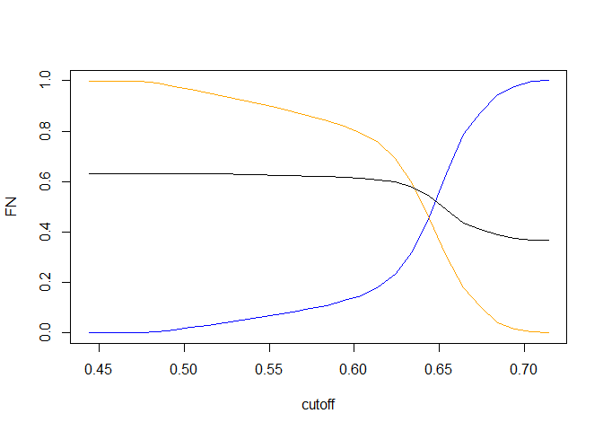

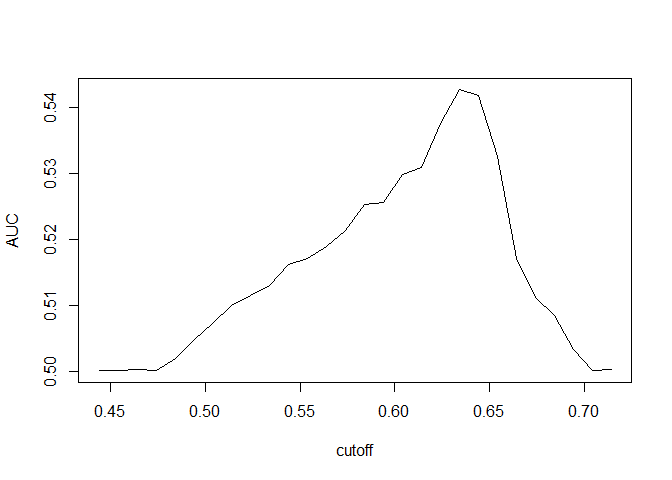

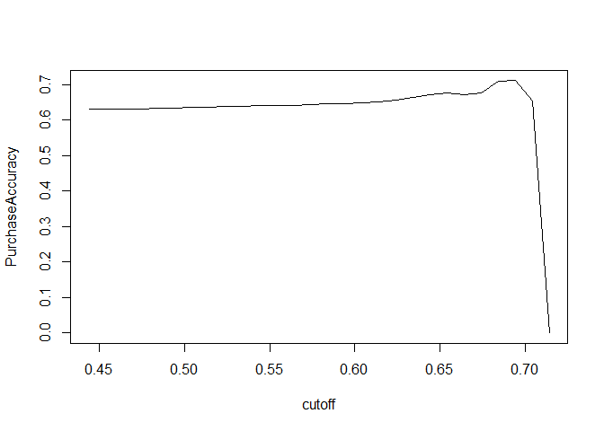

#Best performance of LR

```
##
## lr.pred  Direct   TA
##   Direct   2151 2923
##   TA       3143 6183

## [1] 0.3209971

## [1] 0.593691

## [1] 0.57875
```

-procitati knjigu i po njoj uraditi neke zadatke -obrnuti klasifikaciju da se ide na Direct na na TA aggregaciju podataka -prijaviti se za stanford kurs -a i za kurs logistike -provjeriti da li to vazi za sve greske -uraditi klasifikaciju kada su sve greske ujednacene u stavu koji je najtacniji model MAPE, RMSE,… -uraditi za razliciti vremenske horizonte

```
##          fpr          fnr          tpr          tnr          rec         sens
## 5.936910e-01 3.209971e-01 6.790029e-01 4.063090e-01 6.790029e-01 6.790029e-01
##         spec         prec          rpp         lift            F          ppv
## 4.063090e-01 6.629852e-01 6.476389e-01 7.280751e-05 6.708984e-01 6.629852e-01
##          fdr          npv          for          plr          nlr          dor
## 3.370148e-01 4.239259e-01 5.760741e-01 1.143697e+00 7.900320e-01 1.447660e+00
##          acc          err       microF       macroF     macroRec    macroPrec
## 5.787500e-01 4.212500e-01 5.787500e-01 5.429145e-01 5.426559e-01 5.434555e-01
##          AUC
## 5.426559e-01
```

#Test ROC curve

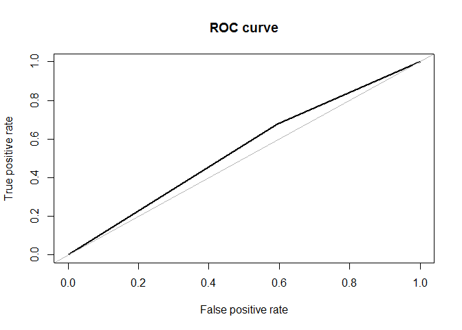

```
## Area under the curve (AUC): 0.543
```

#LDA

```
##         Length Class  Mode
## prior    2     -none- numeric
## counts   2     -none- numeric
## means   20     -none- numeric
## scaling 10     -none- numeric
## lev      2     -none- character
## svd      1     -none- numeric
## N        1     -none- numeric
## call     3     -none- call
## terms    3     terms  call
## xlevels  0     -none- list

## Call:
## lda(marks ~ . - e_acf1 - e_acf10 - x_acf10 - diff1_acf1 - diff1_acf10 -
##     diff2_acf1 - diff2_acf10, data = train.data[, -1])
##
## Prior probabilities of groups:
##    Direct        TA
## 0.3671726 0.6328274
##
## Group means:
##              trend       spike    linearity    curvature     entropy
## Direct -0.11542746  0.04495589 0.0085461458  0.019978976  0.09970306
## TA      0.06393408 -0.02968443 0.0001186355 -0.007003463 -0.05770530
##             x_acf1 seasonal_strength          peak       trough   seas_acf1
## Direct -0.09569374        0.01038209 -0.0105006256 -0.001326643 -0.03260213
## TA      0.05595020       -0.01066217  0.0002364338  0.003263408  0.02111445
##
## Coefficients of linear discriminants:
##                           LD1
## trend              1.57810257
## spike             -0.03875990
## linearity         -0.21911776
## curvature         -0.16235108
## entropy           -1.05972158
## x_acf1            -1.18532155
## seasonal_strength  0.04686404
## peak               0.03846106
## trough             0.05301833
## seas_acf1         -0.86264075
```

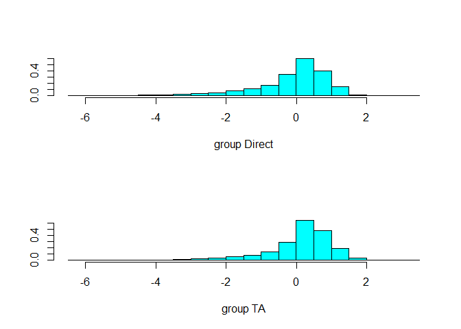

```
##     class posterior.Direct posterior.TA        LD1
## 2      TA        0.4115557    0.5884443 -0.8342254
## 3      TA        0.3535166    0.6464834  0.2238817
## 14     TA        0.3351422    0.6648578  0.5738959
## 16     TA        0.3440680    0.6559320  0.4027596
## 19 Direct        0.5917204    0.4082796 -3.9671933

##
##          Direct   TA
##   Direct    252  214
##   TA       5042 8892

## [1] 0.02350099

## [1] 0.9523989

## [1] 0.635
```

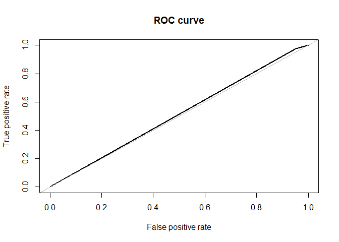

```
## Area under the curve (AUC): 0.512

##          fpr          fnr          tpr          tnr          rec         sens
## 9.523989e-01 2.350099e-02 9.764990e-01 4.760106e-02 9.764990e-01 9.764990e-01
##         spec         prec          rpp         lift            F          ppv
## 4.760106e-02 6.381513e-01 9.676389e-01 7.008031e-05 7.718750e-01 6.381513e-01
##          fdr          npv          for          plr          nlr          dor
## 3.618487e-01 5.407725e-01 4.592275e-01 1.025305e+00 4.937073e-01 2.076746e+00
##          acc          err       microF       macroF     macroRec    macroPrec
## 6.350000e-01 3.650000e-01 6.350000e-01 4.296875e-01 5.120500e-01 5.894619e-01
##          AUC
## 5.120500e-01
```

#QDA

```
##         Length Class  Mode
## prior    2     -none- numeric
## counts   2     -none- numeric
## means   20     -none- numeric
## scaling 10     -none- numeric
## lev      2     -none- character
## svd      1     -none- numeric
## N        1     -none- numeric
## call     3     -none- call
## terms    3     terms  call
## xlevels  0     -none- list

## Call:
## qda(marks ~ . - e_acf1 - e_acf10 - x_acf10 - diff1_acf1 - diff1_acf10 -
##     diff2_acf1 - diff2_acf10, data = train.data[, -1])
##
## Prior probabilities of groups:
##    Direct        TA
## 0.3671726 0.6328274
##
## Group means:
##              trend       spike    linearity    curvature     entropy
## Direct -0.11542746  0.04495589 0.0085461458  0.019978976  0.09970306
## TA      0.06393408 -0.02968443 0.0001186355 -0.007003463 -0.05770530
##             x_acf1 seasonal_strength          peak       trough   seas_acf1
## Direct -0.09569374        0.01038209 -0.0105006256 -0.001326643 -0.03260213
## TA      0.05595020       -0.01066217  0.0002364338  0.003263408  0.02111445

##
##          Direct   TA
##   Direct    701  779
##   TA       4593 8327

## [1] 0.08554799

## [1] 0.8675859

## [1] 0.6269444
```

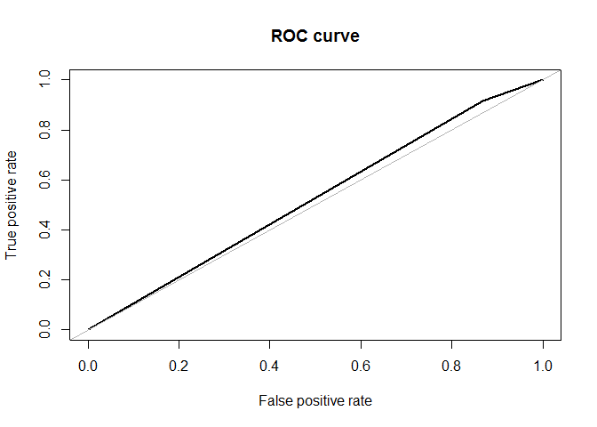

```
## Area under the curve (AUC): 0.523

##          fpr          fnr          tpr          tnr          rec         sens
## 8.675859e-01 8.554799e-02 9.144520e-01 1.324141e-01 9.144520e-01 9.144520e-01
##         spec         prec          rpp         lift            F          ppv
## 1.324141e-01 6.445046e-01 8.972222e-01 7.077802e-05 7.561064e-01 6.445046e-01
##          fdr          npv          for          plr          nlr          dor
## 3.554954e-01 4.736486e-01 5.263514e-01 1.054019e+00 6.460643e-01 1.631446e+00
##          acc          err       microF       macroF     macroRec    macroPrec
## 6.269444e-01 3.730556e-01 6.269444e-01 4.815371e-01 5.234330e-01 5.590766e-01
##          AUC
## 5.234330e-01
```

#KNN

```
##
## knn.pred Direct   TA
##   Direct   1622 1826
##   TA       3672 7280

## [1] 0.2005271

## [1] 0.6936154

## [1] 0.6181944
```

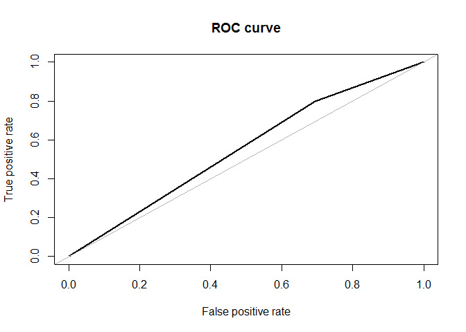

```
## Area under the curve (AUC): 0.553
```

#Choosing the number of k neighbors

```
##
## knn.pred Direct   TA
##   Direct   2453 2787
##   TA       2841 6319
## [1] "cutoff is" "1"
## [1] "the error is"      "0.609166666666667"
## [1] "sensitivity"       "0.693938062815726"
## [1] "specificity"      "46.3354741216471"
## [1] "FN is"             "0.306061937184274"
## [1] "FP is"             "0.536645258783529"
##
## knn.pred Direct   TA
##   Direct   2343 2881
##   TA       2951 6225
## [1] "cutoff is" "2"
## [1] "the error is" "0.595"
## [1] "sensitivity"       "0.683615198770042"
## [1] "specificity"      "44.2576501700038"
## [1] "FN is"             "0.316384801229958"
## [1] "FP is"             "0.557423498299962"
##
## knn.pred Direct   TA
##   Direct   2166 2428
##   TA       3128 6678
## [1] "cutoff is" "3"
## [1] "the error is"      "0.614166666666667"
## [1] "sensitivity"      "0.73336261805403"
## [1] "specificity"      "40.9142425387231"
## [1] "FN is"            "0.26663738194597"
## [1] "FP is"             "0.590857574612769"
##
## knn.pred Direct   TA
##   Direct   2125 2487
##   TA       3169 6619
## [1] "cutoff is" "4"
## [1] "the error is"      "0.607222222222222"
## [1] "sensitivity"       "0.726883373599824"
## [1] "specificity"      "40.1397808840197"
## [1] "FN is"             "0.273116626400176"
## [1] "FP is"             "0.598602191159804"
```

[output cut: 95 more lines]

```
## [1] "the error is"      "0.616736111111111"
## [1] "sensitivity"       "0.821985504063255"
## [1] "specificity"      "26.3694748772195"
## [1] "FN is"             "0.178014495936745"
## [1] "FP is"             "0.736305251227805"
##
## knn.pred Direct   TA
##   Direct   1331 1486
##   TA       3963 7620
## [1] "cutoff is" "15"
## [1] "the error is"      "0.621597222222222"
## [1] "sensitivity"       "0.836810893916099"
## [1] "specificity"      "25.1416698148848"
## [1] "FN is"             "0.163189106083901"
## [1] "FP is"             "0.748583301851152"
```

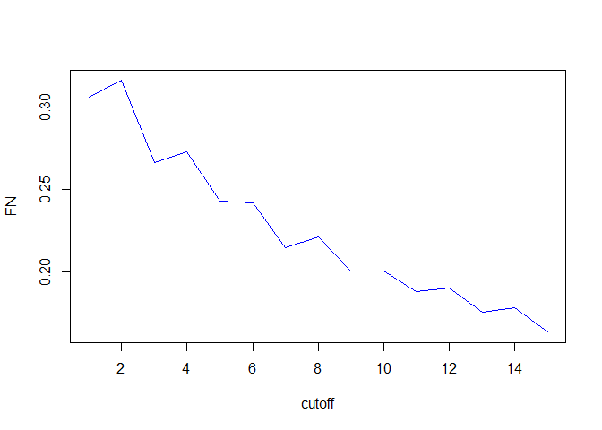

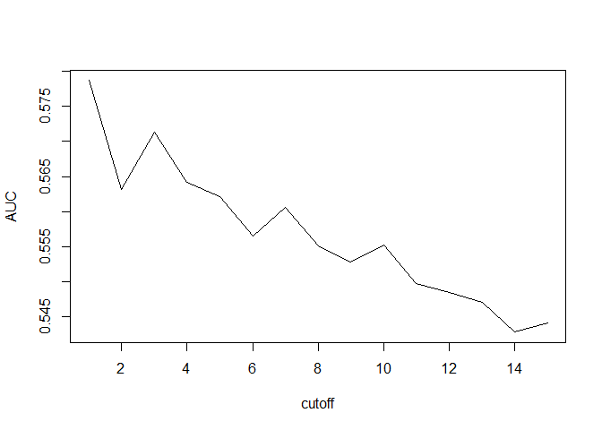

```
##
## knn.pred Direct   TA
##   Direct   2453 2787
##   TA       2841 6319

## [1] 0.3060619

## [1] 0.5366453

## [1] 0.6091667
```

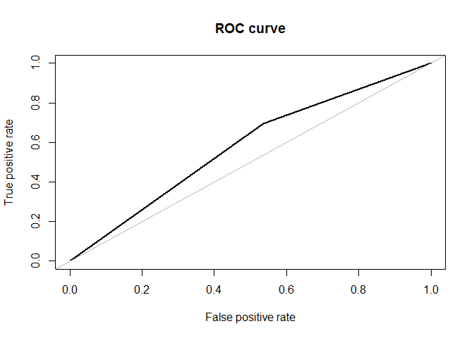

```
## Area under the curve (AUC): 0.579

##          fpr          fnr          tpr          tnr          rec         sens
## 5.366453e-01 3.060619e-01 6.939381e-01 4.633547e-01 6.939381e-01 6.939381e-01
##         spec         prec          rpp         lift            F          ppv
## 4.633547e-01 6.898472e-01 6.361111e-01 7.575743e-05 6.918866e-01 6.898472e-01
##          fdr          npv          for          plr          nlr          dor
## 3.101528e-01 4.681298e-01 5.318702e-01 1.293104e+00 6.605348e-01 1.957662e+00
##          acc          err       microF       macroF     macroRec    macroPrec
## 6.091667e-01 3.908333e-01 6.091667e-01 5.788083e-01 5.786464e-01 5.789885e-01
##          AUC
## 5.786464e-01
```

#Best subsection on whole data set

```
## BICq(q = 1)
## Best Model:
##                       Estimate  Std. Error     z value     Pr(>|z|)
## (Intercept)        0.550985941 0.009553930  57.6711300 0.000000e+00
## trend              0.419929346 0.031985293  13.1288261 2.251193e-39
## spike             -0.007507945 0.010792551  -0.6956599 4.866418e-01
## linearity         -0.036473864 0.011666418  -3.1263977 1.769620e-03
## curvature         -0.037537430 0.009773522  -3.8407269 1.226705e-04
## e_acf1            -0.010358855 0.023563096  -0.4396220 6.602109e-01
## entropy           -0.196343555 0.026936320  -7.2891752 3.118582e-13
## x_acf1            -0.344267443 0.033574047 -10.2539751 1.135744e-24
## diff1_acf1         0.247475208 0.030277935   8.1734507 2.996919e-16
## diff2_acf1        -0.229815130 0.020579946 -11.1669455 5.918116e-29
## seasonal_strength -0.010091445 0.012521128  -0.8059533 4.202698e-01
## peak               0.014632446 0.010107889   1.4476262 1.477216e-01
## trough             0.001964487 0.010199412   0.1926079 8.472661e-01
## seas_acf1         -0.186252370 0.019385437  -9.6078498 7.407976e-22
```

#Mozda moze i ovako ali nisam siguran

```
## [1] "which"  "rsq"    "rss"    "adjr2"  "cp"     "bic"    "outmat" "obj"

## [1] 7
```

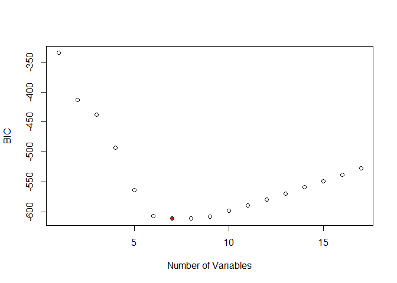

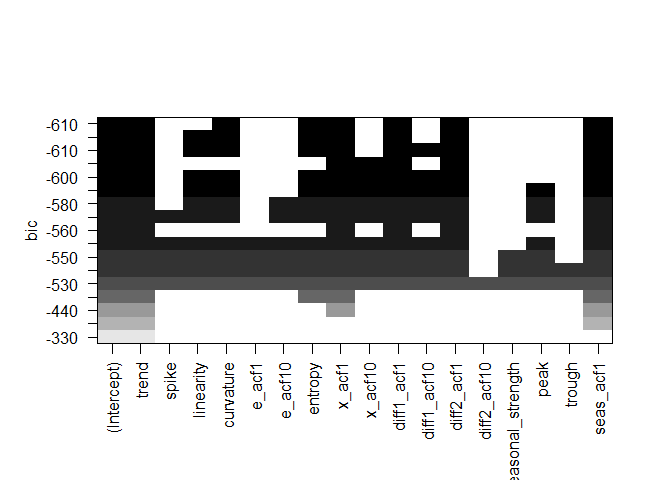

```
##  (Intercept)        trend    curvature      entropy       x_acf1   diff1_acf1
##  1.632687500  0.102052700 -0.008830108 -0.040992327 -0.078997432  0.053672712
##   diff2_acf1    seas_acf1
## -0.050587993 -0.046795735
```

#Lasso

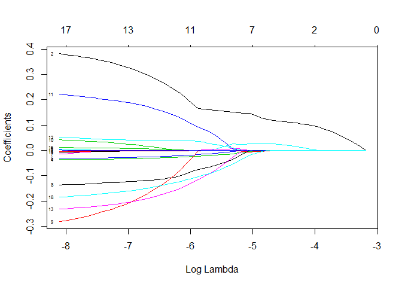

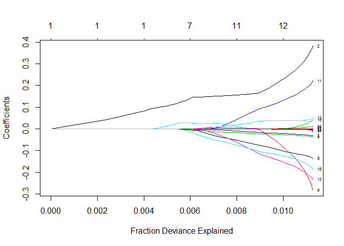

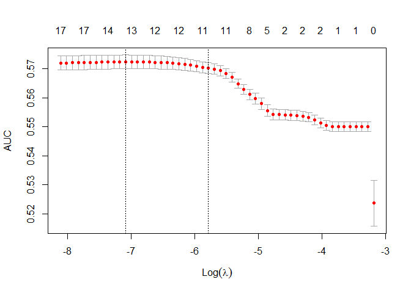

```
## 19 x 1 sparse Matrix of class "dgCMatrix"
##                               1
## (Intercept)        0.5475568176
## (Intercept)        .
## trend              0.1620225867
## spike              .
## linearity         -0.0213864591
## curvature         -0.0147296371
## e_acf1             .
## e_acf10            0.0016902916
## entropy           -0.0702000079
## x_acf1             .
## x_acf10            .
## diff1_acf1         0.0825450608
## diff1_acf10        0.0320424506
## diff2_acf1        -0.1042186504
## diff2_acf10        .
## seasonal_strength -0.0003884554
## peak               .
## trough             .
## seas_acf1         -0.0976072359
```

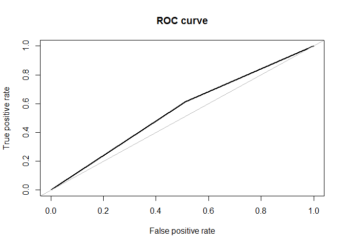

```
## Area under the curve (AUC): 0.550

##          fpr          fnr          tpr          tnr          rec         sens
## 5.128447e-01 3.877663e-01 6.122337e-01 4.871553e-01 6.122337e-01 6.122337e-01
##         spec         prec          rpp         lift            F          ppv
## 4.871553e-01 6.724970e-01 5.756944e-01 7.385207e-05 6.409519e-01 6.724970e-01
##          fdr          npv          for          plr          nlr          dor
## 3.275030e-01 4.220949e-01 5.779051e-01 1.193799e+00 7.959809e-01 1.499784e+00
##          acc          err       microF       macroF     macroRec    macroPrec
## 5.662500e-01 4.337500e-01 5.662500e-01 5.466247e-01 5.496945e-01 5.472960e-01
##          AUC
## 5.496945e-01
```

#Validation Lasso ako zelis da radis preko njega Glupo je mozes sve direktno preko Lasso cros validacije da zavrsis.

#Biranje cutoff-a

#Polinomna regresija oko 300str daje dobre koeficijente za objasnjavanje! probaj ovdje da napravis razne kombinacije sa polynomima

#The poly LR

#GAM

```
##
## Call: gam(formula = marks ~ . - e_acf1 - e_acf10 - x_acf10 - diff1_acf1 -
##     diff1_acf10 - diff2_acf1 - diff2_acf10, family = binomial,
##     data = train.data[, -1])
## Deviance Residuals:
##     Min      1Q  Median      3Q     Max
## -1.7273 -1.3895  0.8930  0.9458  1.5224
##
## (Dispersion Parameter for binomial family taken to be 1)
##
##     Null Deviance: 44179.55 on 33599 degrees of freedom
## Residual Deviance: 43769.7 on 33589 degrees of freedom
## AIC: 43791.7
##
## Number of Local Scoring Iterations: 4
##
## Anova for Parametric Effects
##                      Df Sum Sq Mean Sq  F value    Pr(>F)
## trend                 1    242 242.287 242.2898 < 2.2e-16 ***
## spike                 1      2   1.513   1.5135  0.218621
## linearity             1     25  24.848  24.8486 6.232e-07 ***
## curvature             1      4   3.779   3.7790  0.051908 .
## entropy               1      7   7.049   7.0489  0.007935 **
## x_acf1                1     29  28.906  28.9066 7.646e-08 ***
## seasonal_strength     1     19  19.004  19.0039 1.308e-05 ***
## peak                  1      0   0.469   0.4685  0.493678
## trough                1      0   0.148   0.1483  0.700157
## seas_acf1             1     78  77.793  77.7938 < 2.2e-16 ***
## Residuals         33589  33589   1.000
## ---
## Signif. codes:  0 '***' 0.001 '**' 0.01 '*' 0.05 '.' 0.1 ' ' 1

##
## Call: gam(formula = marks ~ . + s(trend, df = 3) + s(seas_acf1, df = 3) -
##     e_acf1 - e_acf10 - x_acf10 - diff1_acf1 - diff1_acf10 - diff2_acf1 -
##     diff2_acf10, family = binomial, data = train.data[, -1])
## Deviance Residuals:
##     Min      1Q  Median      3Q     Max
## -1.6876 -1.3821  0.8905  0.9457  1.5607
##
```

[output cut: 131 more lines]

```
## curvature
## entropy
## x_acf1
## seasonal_strength
## peak
## trough
## seas_acf1
## s(trend, df = 3)                   2     13.623 0.0011013 **
## s(seas_acf1, df = 3)               2     17.824 0.0001347 ***
## s(linearity, df = 3)               2     27.931  8.61e-07 ***
## s(entropy, df = 3)                 2     80.808 < 2.2e-16 ***
## s(x_acf1, df = 3)                  2      8.019 0.0181433 *
## s(seasonal_strength, df = 3)       2      1.139 0.5656830
## ---
## Signif. codes:  0 '***' 0.001 '**' 0.01 '*' 0.05 '.' 0.1 ' ' 1
```

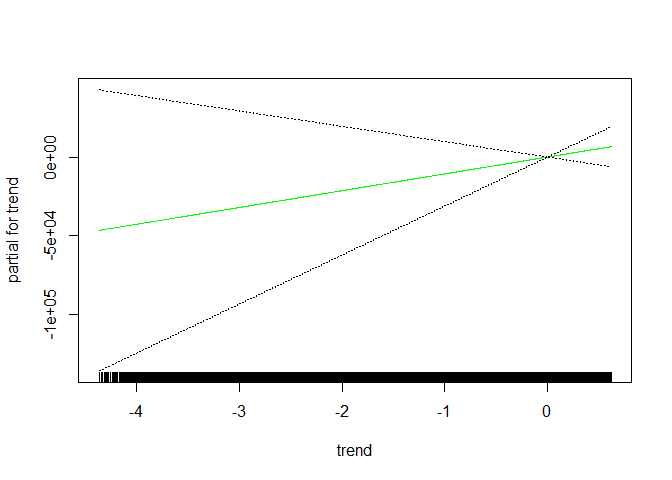

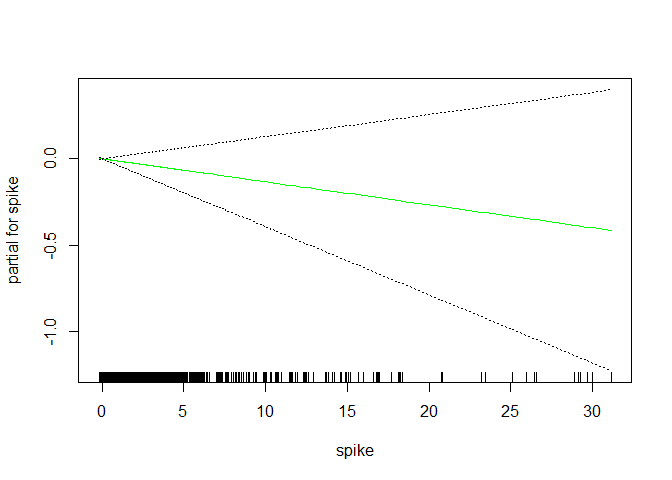

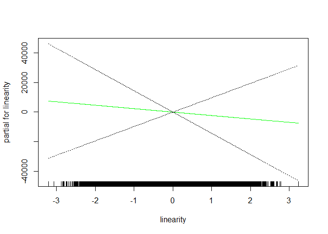

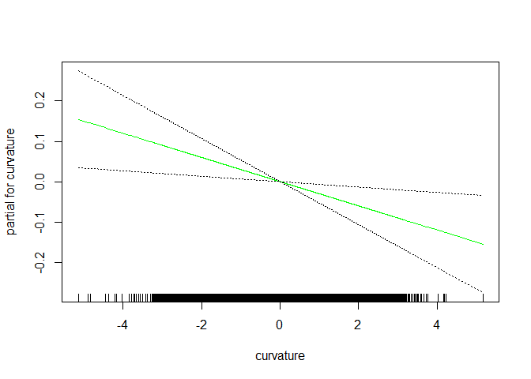

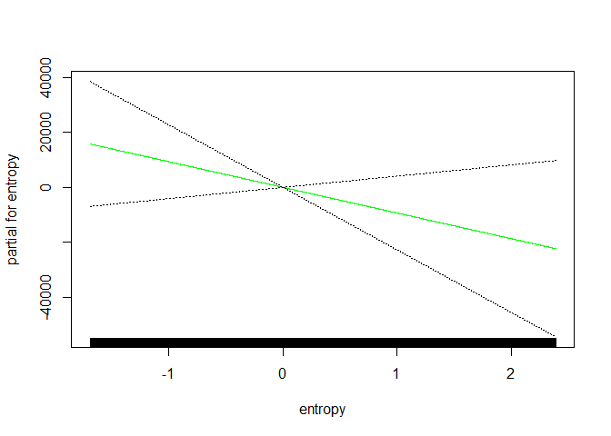

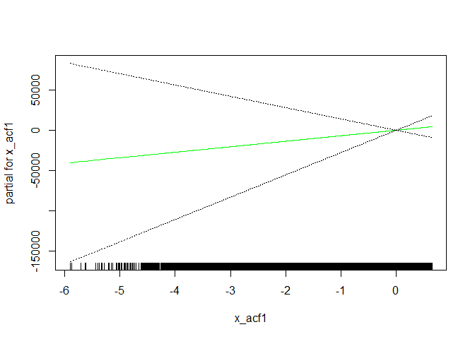

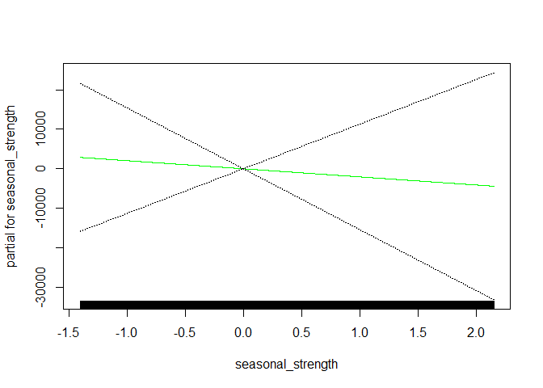

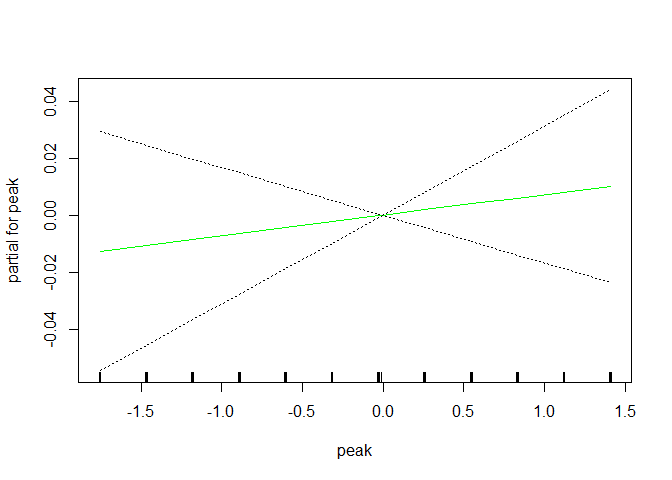

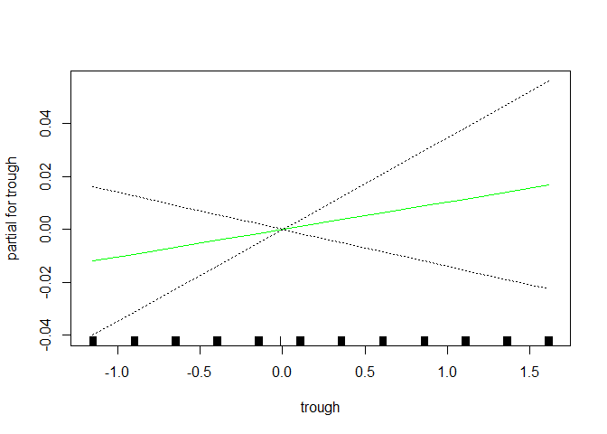